# Proporción de escaños en el parlamento ocupado por mujeres 2020 - Análisis de los resultados

Curso: POL304 - Estadística para el análisis político 2

Integrantes: Xiomara Oshikawa, Kamila Gamarra, Luciana Rojas, Maria Fernanda Carrillo

El objetivo de este reporte es analizar qué factores determinan el porcentaje de presencia femenina en cargos políticos, específicamente en los parlamentos, en diferentes países del mundo.

Consideramos que es un tema importante ya que, a pesar de un notable progreso en la participación política femenina en las últimas décadas, aún existe un gran brecha entre representantes masculinos y femeninos, lo que desencadena en la perpetuación de las condiciones desfavorables de las mujeres y su invisibilización política.

Para la comprensión de la presente investigación, se consideran las siguientes variable:

Variable dependiente: Proporción de escaños ocupados por mujeres en los parlamentos

Variables independientes:

1. Porcentaje de empleo vulnerable femenino
2. Porcentaje de la población activa mujeres
3. Gasto público en educación
4. PBI per cápita nacional del 2015

Se llevarán a cabo los siguientes análisis:

- Realizar un análisis descriptivo y georreferenciado de los escaños en los parlamentos ocupados por mujeres a nivel de cada país.
- Implementar técnicas multivariadas para analizar el efecto de cada variable independiente en la presencia de mujeres en los escaños parlamentarios.
- Aplicar técnicas de reducción de dimensiones para agrupar a los países en función a la proporción de escaños parlamentarios ocupados por mujeres en el año 2020.

## 1. Análisis rápido de los resultados:

|  | codigo | pais | parlamentos2020 | Por_Vulnerable_Femenino_2015 | Poblacion_Act_Mujeres2015 | Gasto_public_educacion_2015 | PBI_2015 |
| --- | --- | --- | --- | --- | --- | --- | --- |
| 1 | AFE |  | 30.1284473 | 78.45549031 | 47.0601377439274 | 16.9629097 | 675.7398763 |
| 2 | AFW |  | 16.34527089 | 87.67787153 | 45.3518171529889 | 13.24398994 | 528.5806067 |
| 3 | AGO | Angola | 30 | 83.74000072 | 49.414205682129 | 8.918776512 | 387.7842672 |
| 4 | ALB | Albania | 29.50819672 | 56.34000015 | 41.8914325440893 | 11.17755032 | 1033.242532 |
| 5 | ARG | Argentina | 40.85603113 | 17.68999952 | 41.8668221891244 | 13.96331024 | 7774.736203 |
| 6 | ARM | Armenia | 23.48484848 | 42.54999924 | 46.8349622060902 | 10.65635967 | 597.4328988 |
| 7 | AUS | Australia | 30.46357616 | 8.21999982 | 45.9271733775535 | 14.08578968 | 20558.9604 |
| 8 | AUT | Austria | 39.3442623 | 7.920000076 | 46.8950611202675 | 10.69347954 | 27183.47593 |
| 9 | AZE | Azerbaiyán | 17.3553719 | 64.00999832 | 49.0223752405609 | 7.631100178 | 573.9165123 |
| 10 | BDI | Burundi | 38.21138211 | 87.81999969 | 51.7280201737745 | 27.49724007 | 128.9389187 |

[output cut: 170 more lines]

En promedio, la proporción de las mujeres que ocupan un escaño en el parlamento de cada país es 24,73. La proporción de mujeres que ocupan un escaño en el parlamento por país se puedeN observar en la tabla a continuación:

|  | codigo | Proporción de escaños parlamentarios ocupados por mujeres |
| --- | --- | --- |
| 1 | AFE | 30.1284473 |
| 2 | AFW | 16.34527089 |
| 3 | AGO | 30 |
| 4 | ALB | 29.50819672 |
| 5 | ARG | 40.85603113 |
| 6 | ARM | 23.48484848 |
| 7 | AUS | 30.46357616 |
| 8 | AUT | 39.3442623 |
| 9 | AZE | 17.3553719 |
| 10 | BDI | 38.21138211 |

[output cut: 170 more lines]

### Distribución de la proporción de escaños parlamentarios ocupados por mujeres en cada país

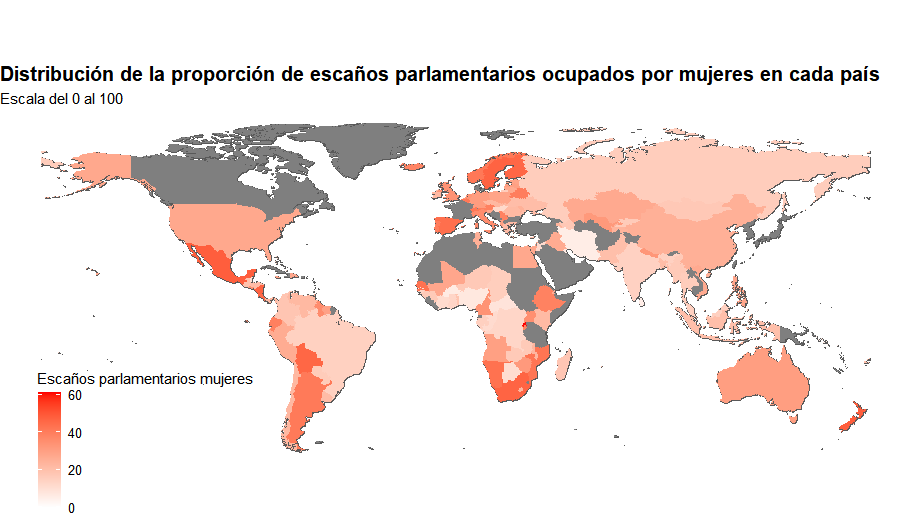

Si se exploran algunos datos descriptivos, se observa que en promedio, la proporción (en una escala de 0-100) de los escaños parlamentarios ocupados por mujeres bordea un 24,73 en cada país estudiado de la presente investigación. Además, el 50% de los países estudiados presentan una proporción de hasta 23,77 de presencia femenina en sus escaños parlamentarios. Entre los que muestran una mayor proporción de escaños ocupados por mujeres en el parlamento se encuentran: Rwanda (61,25), Nueva Zelandia (48,33) y México (48,20). En contraste, los países con menor porcentaje de presencia femenina son Vanuatu (0.0), Maldivas (4.6) y Líbano (4.69)

La distribución de la proporción de escaños ocupados por mujeres se puede observar en el gráfico a continuación:

|  | parlamentos2020 |
| --- | --- |
| Min. | 0.00000 |
| 1st Qu. | 18.21703 |
| Median | 23.76723 |
| Mean | 24.72913 |
| 3rd Qu. | 30.06574 |
| Max. | 61.25000 |

La distribución de escaños ocupados por mujeres en el parlamento se puede observar en el gráfico a continuación:

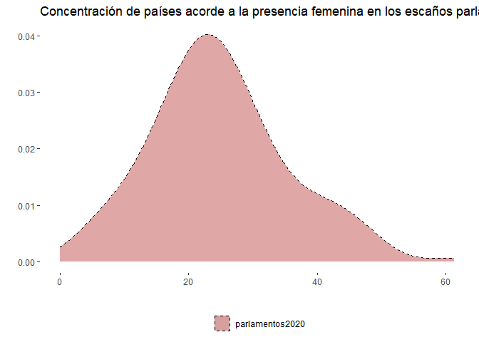

Este esquema cuenta con una distribución asimétrica positiva, en tanto la mediana se encuentra más a la izquierda que la media y el gráfico mismo muestra la campana formada no al centro exacto de la ilustración, sino que esta se encuentra más a la izquierda. Es así, que mediante este gráfico presentado podemos dar cuenta de que, en efecto, la mayoría de países tiene una distribución de mujeres en escaños parlamentarios de cerca de 24,73, es decir que las mujeres, en una considerable cantidad de países, cuentan con un aproximado de 25% de participación dentro de sus respectivos parlamentos nacionales.

Así podemos observar que en efecto la mayoría de estas naciones se concentran entre los valores de 18,22 y 30,07 de participación femenina; siendo esta concentración de países un 0.04. Debemos considerar que el máximo de participación femenina con el que se cuenta es de 61.25. Este es el valor máximo y es representado como una línea que llega a rozar el 0.00 de concentración, ya que solo 1 país (Ruanda) llega a ese valor. Los países que le siguen en proporción de participación política femenina cuentan con valores más cercanos al 48%.

## 2. Técnicas multivariadas para analizar el efecto de cada variable independiente en la presencia de mujeres en los escaños parlamentarios

Efecto de las variables población vulnerable femenina, población activa mujeres, gasto público en educación y PBI

$$\operatorname{\widehat{parlamentos2020}} = 4.63 -
0.06(\operatorname{Por\_Vulnerable\_Femenino\_2015}) +
0.33(\operatorname{Poblacion\_Act\_Mujeres2015}) +
0.51(\operatorname{Gasto\_public\_educacion\_2015}) +
0(\operatorname{PBI\_2015})$$

OLS

|  | Model 1 |
| --- | --- |
| (Intercept) | 4.629 |
|  | (4.435) |
| Por_Vulnerable_Femenino_2015 | -0.064* |
|  | (0.030) |
| Poblacion_Act_Mujeres2015 | 0.329*** |
|  | (0.095) |
| Gasto_public_educacion_2015 | 0.515** |
|  | (0.169) |
| PBI_2015 | 0.0002* |
|  | (0.0001) |
| Num.Obs. | 180 |
| R2 | 0.222 |
| R2 Adj. | 0.204 |
| AIC | 1322.8 |
| BIC | 1342.0 |
| Log.Lik. | -655.405 |
| F | 12.497 |
| RMSE | 9.23 |

+ p < 0.1, * p < 0.05, ** p < 0.01, *** p < 0.001

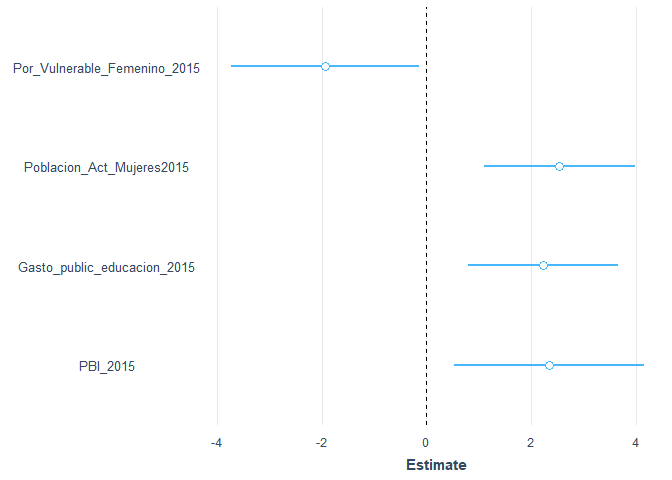

En primer lugar, vemos que el p-value, al ser menor a 0.05, determinamos que nuestro modelo es válido. Segundo, vemos el coeficiente de determinación(r2), que es O.2044 y nos indica que nuestro modelo predice el 20.44%, es decir, que la variabilidad de la proporción de mujeres en los escaños parlamentarios es explicada por las demás variables en un 20.44%. Tercero, podemos ver que todas las variables son significativas. Por un lado, la variable de porcentaje de empleo vulnerable femenino tiene una magnitud de 0.064 y efecto inverso, es decir que, si el porcentaje de empleo vulnerable femenino aumenta en una unidad, la proporción de mujeres en los escaños parlamentarios disminuirá en 0.064. Por otro lado, las variables porcentaje de población activa de mujeres, gasto público en educación, y PBI tiene un efecto directo, y una magnitud de 0.329, 0.515 y 0.0002 respectivamente.

Esto quiere decir que si el porcentaje de población activa femenina, la inversión en educación y el PBI aumentan en una unidad, la presencia femenina en los escaños parlamentarios aumentará en 0.329, 0.515 y 0.0002 respectivamente. Finalmente, La variable más significativa, es decir la que tiene menor probabilidad de ser 0, es porcentaje de población activa mujeres (0.001), seguida del gasto público en educación (0.01) y finalmente el porcentaje de empleo vulnerable femenino y PBI (0.05). Frente a estos resultados podemos decir que los países que tengan mayor PBI, mayor inversión en educación, mayor porcentaje de mujeres activas y menor porcentaje de empleo vulnerable serán los que tengan mayor presencia de mujeres en los escaños parlamentarios.

## 3. Técnicas de reducción de dimensiones

Vamos a agrupar a los distintos países en función a sus características sociodemográficas, siguiendo técnicas de reducción de dimensiones. Tenemos tres estrategias: Partición (PAM), Jerárquica Aglomerativa (AGNES) y Jerárquica Divisiva (DIANA).

### Clusterización vía PAM

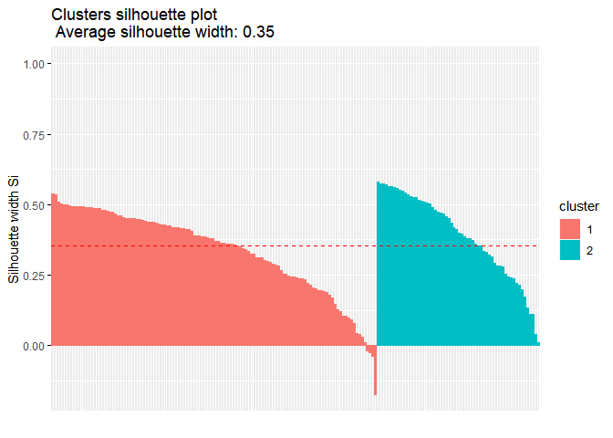

### Clusterización vía AGNES

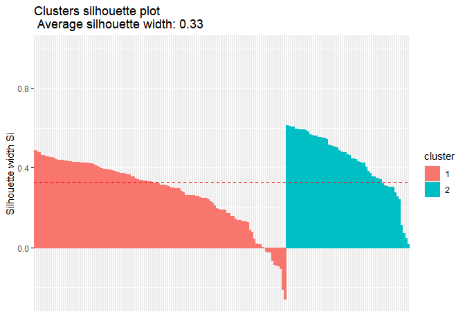

### Clusterización vía DIANA

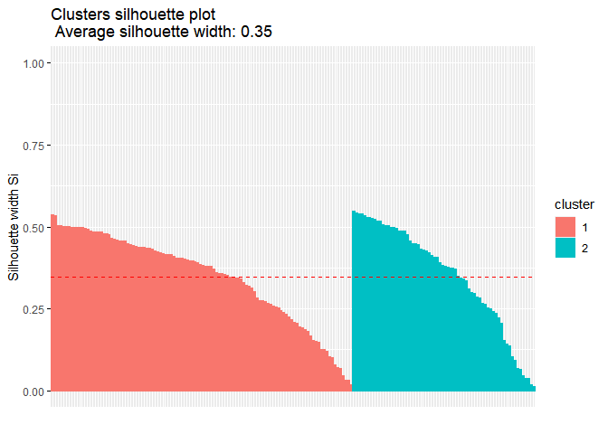

Las tres técnicas sugieren 2 clusters. Tanto la técnica de PAM como la de DIANA nos da un promedio de 0.35, mientras que la de AGNES, de 0.33. Así mismo, en la técnica de PAM y AGNES se encuentran 4 y 11 casos mal clusterizados respectivamente, mientras que, por DIANA, no se tiene ninguno. Frente a estos resultados, se decide optar por la técnica jerárquica divisiva (DIANA) al ser la más adecuada para nuestros datos

### Características de cada conglomerado obstenido:

| diana | Vulnerable_Femenino | Población_Activa_Mujeres | Gasto_educación | PBI |
| --- | --- | --- | --- | --- |
| Baja presencia de mujeres en el parlamento | 61.95794 | 41.04728 | 15.85813 | 1204.844 |
| Alta presencia de mujeres en el parlamento | 11.57400 | 43.33276 | 13.03546 | 13765.952 |

### Número de países por cada conglomerado:

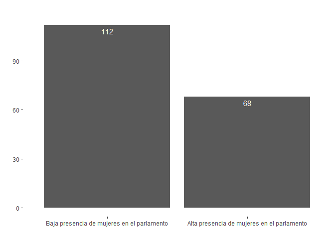

Así es que, mediante la categorización de los países en dos grupos, número óptimo según las tres técnicas anteriormente ejecutadas, es que podemos observar en este gráfico que la categoría que corresponde a una “baja presencia de mujeres en el parlamento” cuenta con 112 países. Estos países cuentan con un elevado número de vulnerabilidad en empleo femenino, ya que representa un 61.95%. Este porcentaje es alto si se compara al grupo de países que constituyen una “alta presencia de mujeres en el parlamento” ya que los 68 países (casi una proporción de 1 a 2 del total de países) que la conforman cuentan con un porcentaje de vulnerabilidad de empleo femenino de tan solo un 11.57%.

Este parece ser un indicador sustancialmente diferenciador, ya que en el factor de la población activa se tiene una diferencia menor (2.28548%) entre el grupo de la alta presencia (43.33276%) y el de baja (41.04728).Así mismo, se ve una diferencia de 2 puntos en la variable de gasto público en educación, sorprendentemente a favor de los países con baja presencia,quienes cuentan con un promedio de 15.86 a diferencia de los de alta presencia que cuentan con 13.04. Finalmente, la varaible del PBI per cápita de cada país muestra otra desigualdad monumental, debido a que el PBI de los países con baja presencia cuentan con 1204.844 dólares, mientras los de alta presencia con 13765.952 dólares; una disparidad de más de 12500 dólares.

### Análisis geoespacial de clusters:

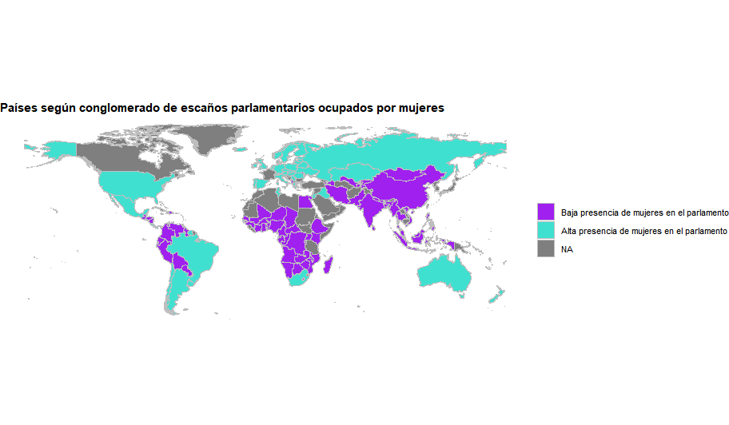

El gráfico adjunto mide la intensidad de la presencia de mujeres en escaños parlamentarios a nivel global. La leyenda ubicada a la derecha ilustra este punto. Así, el color turquesa sugiere una alta presencia femenina, el morado una baja y el gris los datos perdidos de la data producida. Por un lado, apreciamos que la región de Europa oriental, Eurasia, Oceanía, el sur de África, Estados Unidos, Argentina y Brasil tiene alta presencia de mujeres. Por otro lado, el resto de Estados latinoamericanos, la región del África subsahariana y el sudeste asiático presentan bajos índices de presencia de actividad femenina en los escaños parlamentarios. Por último, resalta la ausencia de data acerca de la región del Magreb, Canadá, Turquía y ciertos Estados del sudeste asiático.

Frente a estos resultados, se puede determinar que los clusters son de ayuda para una mejor organización de datos, sin embargo, no siempre pueden identificar un caso atípico. Esto debido a que Brasil, por ejemplo, está ubicado dentro de los países con alta presencia femenina en los escaños parlamentarios debido a que cumple con las variables independientes como un alto PBI, alta inversión en educación, alto porcentaje de mujeres activas y bajo porcentaje de vulnerabilidad. Sin embargo, Brasil solo cuenta con un 14.62% de presencia femenina en los escaños parlamentarios, por lo que en realidad debería ser catalogado como de baja presencia de mujeres.

## Conclusiones

Es así que, mediante el estudio de las 4 variables independientes (porcentaje de empleo vulnerable femenino, porcentaje de la población activa de mujeres, gasto público en educación y PBI per cápita nacional) concluimos que todas estas son significativas, aunque su grado de relevancia varia. Por ejemplo, la cantidad de población activa femenina es sumamente influyente, mientras el PBI tiene un menor grado de influencia. Aunque, cabe recalcar que el modelo construido en base a las cuatro variables cuenta con un 20% de confiabilidad, apto para poder analizar variaciones del porcentaje de escaños en parlamentos a nivel global.

En segundo lugar, mediante el análisis de ‘clusters’ (o conglomerados) y el empleo de las técnicas de agrupación, se dividió a los países en dos grupos: alta participación política femenina (68 países) o baja participación de mujeres en los escaños parlamentarios (112 países). Ambos grupos cuentan con importantes diferencias, especialmente entre las variables de población vulnerable femenina y PBI per cápita. Enfocándonos en un análisis geoespacial, podemos comprobar que, zonas como Europa norte cuenta con una alta participación, mientras casi la totalidad de África y Oriente registran una participación baja. En el caso de Latinoamérica, esta se identifica con una dinámica variada puesto que presenta países con alta y baja participación al mismo tiempo.

Finalmente, como puntos a mejorar en este trabajo se tiene las limitaciones que muestran las clusterizaciones para identificar casos atípicos. En este sentido, para futuros trabajos de investigación sería interesante poder identificar esos casos atípicos y realizar un análisis más exhaustivo de ellos.